# Análisis Económico con Tidyverse

Variaciones, Indexación y Deflactación de Variables

Análisis con R y Tidyverse

2025-11-01

# Introducción

Este notebook explora cuatro conceptos fundamentales en el análisis económico:

1. **Diferencias entre variables y variaciones porcentuales** (interanual, intermensual, etc.)
2. **Indexación de variables** (números índice)
3. **Deflactación de variables** y cambios de base del deflactor
4. **Tasa de Crecimiento Anual Acumulada (TCAA/CAGR)**

Utilizaremos el ecosistema **Tidyverse** para todas las transformaciones y visualizaciones.

```r
library(tidyverse)
library(lubridate)
library(scales)
library(knitr)

# Configurar tema de gráficos
theme_set(theme_minimal(base_size = 12))
```

# 1. Diferencias y Variaciones Porcentuales

## 1.1 Conceptos Teóricos

Las **diferencias absolutas** miden el cambio en unidades originales de la variable:

$$\Delta X_t = X_t - X_{t-1}$$

Las **variaciones porcentuales** miden el cambio relativo:

$$\text{Var}\% = \frac{X_t -
X_{t-1}}{X_{t-1}} \times 100$$

### Tipos de variaciones más comunes:

- **Intermensual**: comparación con el mes anterior
- **Interanual**: comparación con el mismo mes del año anterior
- **Acumulada**: variación desde el inicio del año hasta el periodo actual
- **Promedio móvil**: suaviza fluctuaciones estacionales

## 1.2 Datos de Ejemplo

Vamos a crear un dataset simulado de ventas mensuales con componente estacional:

```r
set.seed(123)

# Crear serie temporal de 3 años
datos_ventas <- tibble(
  fecha = seq.Date(from = as.Date("2022-01-01"),
                   to = as.Date("2024-12-01"),
                   by = "month"),
  año = year(fecha),
  mes = month(fecha),
  trimestre = quarter(fecha)
) %>%
  mutate(
    # Tendencia creciente + estacionalidad + ruido
    ventas_nominales = 100000 +
                      (row_number() * 500) + # tendencia
                      sin(mes * pi/6) * 8000 + # estacionalidad
                      rnorm(n(), 0, 2000) # ruido
  ) %>%
  mutate(ventas_nominales = round(ventas_nominales, 0))

# Visualizar los primeros registros
head(datos_ventas, 12) %>% kable()
```

| fecha | año | mes | trimestre | ventas_nominales |
| --- | --- | --- | --- | --- |
| 2022-01-01 | 2022 | 1 | 1 | 103379 |
| 2022-02-01 | 2022 | 2 | 1 | 107468 |
| 2022-03-01 | 2022 | 3 | 1 | 112617 |
| 2022-04-01 | 2022 | 4 | 2 | 109069 |
| 2022-05-01 | 2022 | 5 | 2 | 106759 |
| 2022-06-01 | 2022 | 6 | 2 | 106430 |
| 2022-07-01 | 2022 | 7 | 3 | 100422 |
| 2022-08-01 | 2022 | 8 | 3 | 94542 |
| 2022-09-01 | 2022 | 9 | 3 | 95126 |
| 2022-10-01 | 2022 | 10 | 4 | 97180 |
| 2022-11-01 | 2022 | 11 | 4 | 103948 |
| 2022-12-01 | 2022 | 12 | 4 | 106720 |

## 1.3 Cálculo de Variaciones con Tidyverse

```r
datos_ventas <- datos_ventas %>%
  arrange(fecha) %>%
  mutate(
    # Diferencia absoluta intermensual
    dif_intermensual = ventas_nominales - lag(ventas_nominales, 1),

    # Variación porcentual intermensual
    var_intermensual = (ventas_nominales / lag(ventas_nominales, 1) - 1) * 100,

    # Variación porcentual interanual (12 meses)
    var_interanual = (ventas_nominales / lag(ventas_nominales, 12) - 1) * 100,

    # Acumulada anual (vs mismo periodo año anterior)
    ventas_acum_año = cumsum(ventas_nominales * (año == max(año))),
    ventas_acum_año_ant = lag(ventas_acum_año, 12),
    var_acumulada = (ventas_acum_año / ventas_acum_año_ant - 1) * 100,

    # Promedio móvil de 3 meses
    promedio_movil_3m = slider::slide_dbl(ventas_nominales, mean,
                                          .before = 2, .after = 0,
                                          .complete = TRUE)
  )

# Mostrar ejemplo de cálculos
datos_ventas %>%
  filter(fecha >= "2023-01-01", fecha <= "2023-06-01") %>%
  select(fecha, ventas_nominales, dif_intermensual,
         var_intermensual, var_interanual) %>%
  kable(digits = 2)
```

| fecha | ventas_nominales | dif_intermensual | var_intermensual | var_interanual |
| --- | --- | --- | --- | --- |
| 2023-01-01 | 111302 | 4582 | 4.29 | 7.66 |
| 2023-02-01 | 114150 | 2848 | 2.56 | 6.22 |
| 2023-03-01 | 114388 | 238 | 0.21 | 1.57 |
| 2023-04-01 | 118502 | 4114 | 3.60 | 8.65 |
| 2023-05-01 | 113496 | -5006 | -4.22 | 6.31 |
| 2023-06-01 | 105067 | -8429 | -7.43 | -1.28 |

## 1.4 Visualización de Variaciones

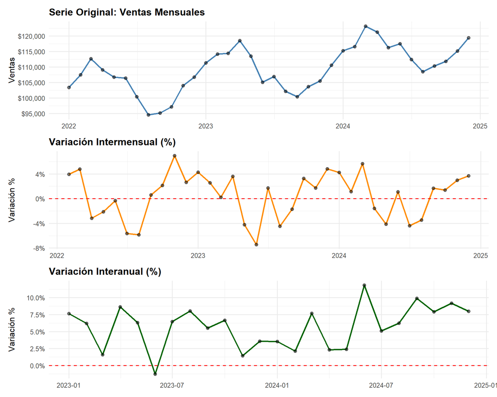

```r
# Gráfico de la serie original
p1 <- datos_ventas %>%
  ggplot(aes(x = fecha, y = ventas_nominales)) +
  geom_line(color = "steelblue", size = 1) +
  geom_point(size = 2, alpha = 0.5) +
  scale_y_continuous(labels = dollar_format(prefix = "$", big.mark = ",")) +
  labs(title = "Serie Original: Ventas Mensuales",
       x = NULL, y = "Ventas") +
  theme(plot.title = element_text(face = "bold"))

# Gráfico de variación intermensual
p2 <- datos_ventas %>%
  filter(!is.na(var_intermensual)) %>%
  ggplot(aes(x = fecha, y = var_intermensual)) +
  geom_line(color = "darkorange", size = 1) +
  geom_point(size = 2, alpha = 0.5) +
  geom_hline(yintercept = 0, linetype = "dashed", color = "red") +
  scale_y_continuous(labels = percent_format(scale = 1)) +
  labs(title = "Variación Intermensual (%)",
       x = NULL, y = "Variación %") +
  theme(plot.title = element_text(face = "bold"))

# Gráfico de variación interanual
p3 <- datos_ventas %>%
  filter(!is.na(var_interanual)) %>%
  ggplot(aes(x = fecha, y = var_interanual)) +
  geom_line(color = "darkgreen", size = 1) +
  geom_point(size = 2, alpha = 0.5) +
  geom_hline(yintercept = 0, linetype = "dashed", color = "red") +
  scale_y_continuous(labels = percent_format(scale = 1)) +
  labs(title = "Variación Interanual (%)",
       x = NULL, y = "Variación %") +
  theme(plot.title = element_text(face = "bold"))

# Combinar gráficos
library(patchwork)
p1 / p2 / p3
```

## 1.5 Comparación: Diferencia Absoluta vs Relativa

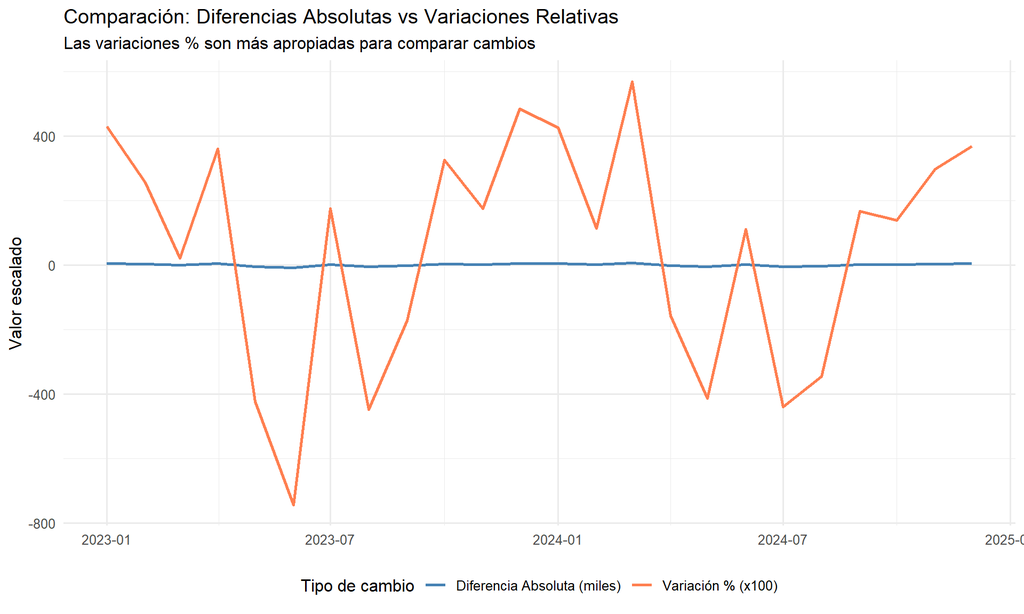

```r
datos_ventas %>%
  filter(año >= 2023) %>%
  ggplot(aes(x = fecha)) +
  geom_line(aes(y = dif_intermensual / 1000, color = "Diferencia Absoluta (miles)"),
            size = 1) +
  geom_line(aes(y = var_intermensual * 100, color = "Variación % (x100)"),
            size = 1) +
  scale_color_manual(values = c("steelblue", "coral")) +
  labs(title = "Comparación: Diferencias Absolutas vs Variaciones Relativas",
       subtitle = "Las variaciones % son más apropiadas para comparar cambios",
       x = NULL, y = "Valor escalado",
       color = "Tipo de cambio") +
  theme(legend.position = "bottom")
```

**Interpretación**: Las variaciones porcentuales son más útiles para:

- Comparar cambios en variables de diferentes magnitudes
- Interpretar la importancia relativa del cambio
- Estandarizar comparaciones entre diferentes periodos

# 2. Indexación de Variables

## 2.1 Conceptos de Números Índice

Un **número índice** transforma una serie temporal a una base de referencia igual a 100:

$$I_t = \frac{X_t}{X_{base}} \times
100$$

**Ventajas de la indexación:**

- Facilita comparaciones entre series de diferentes unidades
- Muestra claramente la evolución relativa
- Elimina el efecto de la magnitud inicial

## 2.2 Crear Índices con Base Diferente

```r
# Definir diferentes bases
fecha_base_2022 <- as.Date("2022-01-01")
fecha_base_2023 <- as.Date("2023-01-01")

datos_ventas <- datos_ventas %>%
  mutate(
    # Índice base 2022 = 100
    indice_base_2022 = (ventas_nominales /
                         ventas_nominales[fecha == fecha_base_2022]) * 100,

    # Índice base 2023 = 100
    indice_base_2023 = (ventas_nominales /
                         ventas_nominales[fecha == fecha_base_2023]) * 100,

    # Índice promedio año 2022 = 100
    promedio_2022 = mean(ventas_nominales[año == 2022]),
    indice_promedio_2022 = (ventas_nominales / first(promedio_2022)) * 100
  )

# Visualizar índices
datos_ventas %>%
  filter(fecha <= "2024-06-01") %>%
  select(fecha, ventas_nominales, indice_base_2022,
         indice_base_2023, indice_promedio_2022) %>%
  tail(12) %>%
  kable(digits = 2)
```

| fecha | ventas_nominales | indice_base_2022 | indice_base_2023 | indice_promedio_2022 |
| --- | --- | --- | --- | --- |
| 2023-07-01 | 106903 | 103.41 | 96.05 | 103.15 |
| 2023-08-01 | 102126 | 98.79 | 91.76 | 98.54 |
| 2023-09-01 | 100364 | 97.08 | 90.17 | 96.84 |
| 2023-10-01 | 103636 | 100.25 | 93.11 | 100.00 |
| 2023-11-01 | 105448 | 102.00 | 94.74 | 101.75 |
| 2023-12-01 | 110542 | 106.93 | 99.32 | 106.66 |
| 2024-01-01 | 115250 | 111.48 | 103.55 | 111.20 |
| 2024-02-01 | 116555 | 112.75 | 104.72 | 112.46 |
| 2024-03-01 | 123176 | 119.15 | 110.67 | 118.85 |
| 2024-04-01 | 121235 | 117.27 | 108.92 | 116.98 |
| 2024-05-01 | 116224 | 112.43 | 104.42 | 112.14 |
| 2024-06-01 | 117508 | 113.67 | 105.58 | 113.38 |

## 2.3 Comparación Visual de Índices

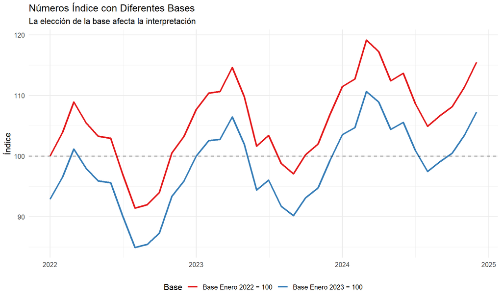

```r
datos_ventas %>%
  select(fecha, indice_base_2022, indice_base_2023) %>%
  pivot_longer(cols = starts_with("indice"),
               names_to = "tipo_indice",
               values_to = "valor") %>%
  mutate(tipo_indice = case_when(
    tipo_indice == "indice_base_2022" ~ "Base Enero 2022 = 100",
    tipo_indice == "indice_base_2023" ~ "Base Enero 2023 = 100"
  )) %>%
  ggplot(aes(x = fecha, y = valor, color = tipo_indice)) +
  geom_line(size = 1.2) +
  geom_hline(yintercept = 100, linetype = "dashed", alpha = 0.5) +
  scale_color_brewer(palette = "Set1") +
  labs(title = "Números Índice con Diferentes Bases",
       subtitle = "La elección de la base afecta la interpretación",
       x = NULL, y = "Índice",
       color = "Base") +
  theme(legend.position = "bottom")
```

## 2.4 Cambio de Base

Cuando necesitamos cambiar la base de un índice existente:

$$I_{t}^{nueva} =
\frac{I_{t}^{vieja}}{I_{base\_nueva}^{vieja}} \times 100$$

```r
# Supongamos que tenemos un índice con base 2022
# y queremos cambiarlo a base 2023

datos_ventas <- datos_ventas %>%
  mutate(
    # Valor del índice antiguo en la nueva fecha base
    valor_indice_en_nueva_base = indice_base_2022[fecha == fecha_base_2023],

    # Índice con nueva base (calculado desde índice viejo)
    indice_cambiado = (indice_base_2022 / first(valor_indice_en_nueva_base)) * 100
  )

# Verificar que el cambio de base es correcto
datos_ventas %>%
  filter(fecha >= "2023-01-01", fecha <= "2023-12-01") %>%
  select(fecha, indice_base_2023, indice_cambiado) %>%
  head(6) %>%
  kable(digits = 2,
        caption = "Comparación: Índice directo vs Índice con base cambiada")
```

Comparación: Índice directo vs Índice con base cambiada

| fecha | indice_base_2023 | indice_cambiado |
| --- | --- | --- |
| 2023-01-01 | 100.00 | 100.00 |
| 2023-02-01 | 102.56 | 102.56 |
| 2023-03-01 | 102.77 | 102.77 |
| 2023-04-01 | 106.47 | 106.47 |
| 2023-05-01 | 101.97 | 101.97 |
| 2023-06-01 | 94.40 | 94.40 |

# 3. Deflactación de Variables

## 3.1 Conceptos Teóricos

**Deflactar** significa expresar valores nominales en términos reales, eliminando el efecto de la inflación:

$$X_{real,t} = \frac{X_{nominal,t}}{IPC_t}
\times 100$$

Donde $IPC_t$ es el Índice de Precios al Consumidor en el periodo $t$.

**Valores nominales vs reales:**

- **Nominales**: expresados en pesos corrientes (del momento)
- **Reales**: expresados en pesos constantes (de un periodo base)

## 3.2 Crear un IPC Simulado

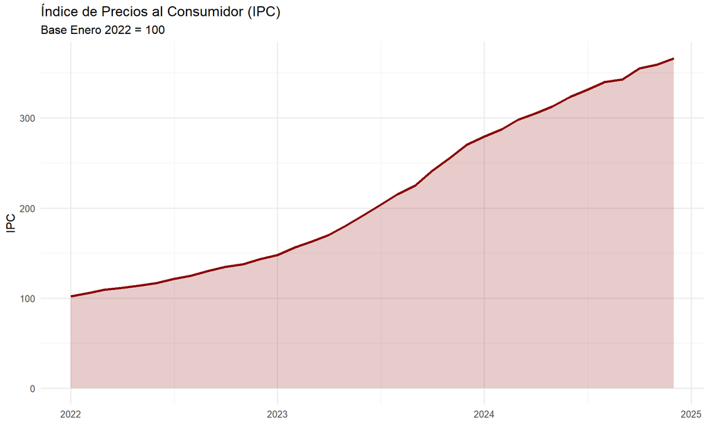

```r
# Crear un IPC con inflación variable
set.seed(456)

ipc_data <- tibble(
  fecha = seq.Date(from = as.Date("2022-01-01"),
                   to = as.Date("2024-12-01"),
                   by = "month")
) %>%
  mutate(
    # Simular inflación mensual variable
    inflacion_mensual = case_when(
      fecha < "2023-01-01" ~ rnorm(n(), 0.03, 0.01), # ~3% mensual
      fecha < "2024-01-01" ~ rnorm(n(), 0.05, 0.015), # ~5% mensual
      TRUE ~ rnorm(n(), 0.025, 0.01) # ~2.5% mensual
    ),
    inflacion_mensual = pmax(inflacion_mensual, 0) # evitar negativa
  ) %>%
  mutate(
    # Construir IPC acumulativo (base enero 2022 = 100)
    ipc = 100 * cumprod(1 + inflacion_mensual)
  )

# Unir con datos de ventas
datos_completos <- datos_ventas %>%
  left_join(ipc_data, by = "fecha")

# Visualizar IPC
ipc_data %>%
  ggplot(aes(x = fecha, y = ipc)) +
  geom_line(color = "darkred", size = 1.2) +
  geom_area(alpha = 0.2, fill = "darkred") +
  labs(title = "Índice de Precios al Consumidor (IPC)",
       subtitle = "Base Enero 2022 = 100",
       x = NULL, y = "IPC") +
  scale_y_continuous(labels = comma)
```

## 3.3 Deflactar Ventas Nominales

```r
datos_completos <- datos_completos %>%
  mutate(
    # Deflactar ventas (base enero 2022)
    ventas_reales_base_2022 = (ventas_nominales / ipc) * 100,

    # Calcular variación interanual real
    var_interanual_real = (ventas_reales_base_2022 /
                            lag(ventas_reales_base_2022, 12) - 1) * 100
  )

# Comparar valores nominales y reales
datos_completos %>%
  filter(fecha >= "2023-01-01", fecha <= "2023-12-01") %>%
  select(fecha, ventas_nominales, ipc, ventas_reales_base_2022) %>%
  kable(digits = 2, format.args = list(big.mark = ","))
```

| fecha | ventas_nominales | ipc | ventas_reales_base_2022 |
| --- | --- | --- | --- |
| 2023-01-01 | 111,302 | 147.94 | 75,235.68 |
| 2023-02-01 | 114,150 | 156.24 | 73,059.57 |
| 2023-03-01 | 114,388 | 162.50 | 70,394.32 |
| 2023-04-01 | 118,502 | 170.00 | 69,708.86 |
| 2023-05-01 | 113,496 | 180.23 | 62,974.18 |
| 2023-06-01 | 105,067 | 191.66 | 54,818.88 |
| 2023-07-01 | 106,903 | 203.02 | 52,655.63 |
| 2023-08-01 | 102,126 | 215.40 | 47,411.91 |
| 2023-09-01 | 100,364 | 224.84 | 44,638.62 |
| 2023-10-01 | 103,636 | 241.33 | 42,943.27 |
| 2023-11-01 | 105,448 | 255.36 | 41,293.88 |
| 2023-12-01 | 110,542 | 270.34 | 40,890.20 |

## 3.4 Comparación Visual: Nominal vs Real

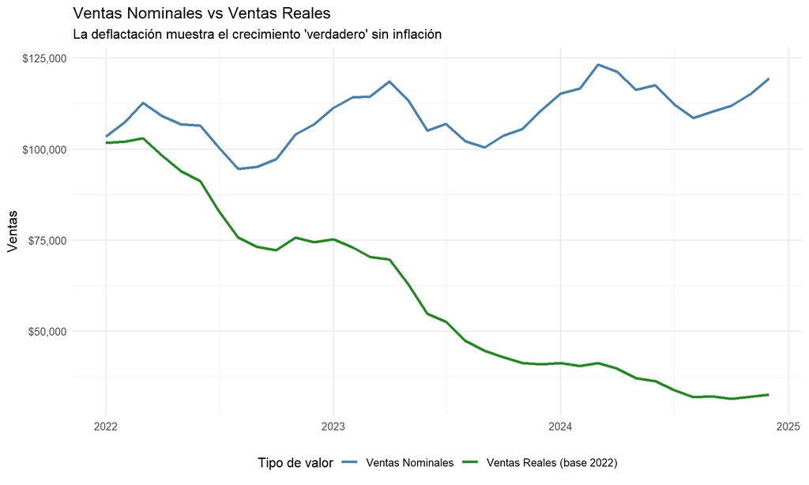

```r
datos_completos %>%
  select(fecha, ventas_nominales, ventas_reales_base_2022) %>%
  pivot_longer(cols = c(ventas_nominales, ventas_reales_base_2022),
               names_to = "tipo",
               values_to = "valor") %>%
  mutate(tipo = case_when(
    tipo == "ventas_nominales" ~ "Ventas Nominales",
    tipo == "ventas_reales_base_2022" ~ "Ventas Reales (base 2022)"
  )) %>%
  ggplot(aes(x = fecha, y = valor, color = tipo)) +
  geom_line(size = 1.2) +
  scale_y_continuous(labels = dollar_format(prefix = "$", big.mark = ",")) +
  scale_color_manual(values = c("steelblue", "forestgreen")) +
  labs(title = "Ventas Nominales vs Ventas Reales",
       subtitle = "La deflactación muestra el crecimiento 'verdadero' sin inflación",
       x = NULL, y = "Ventas",
       color = "Tipo de valor") +
  theme(legend.position = "bottom")
```

## 3.5 Cambio de Base del Deflactor

A veces necesitamos cambiar la base del deflactor (por ejemplo, de base 2022 a base 2023):

```r
# Calcular IPC con nueva base (2023)
fecha_nueva_base <- as.Date("2023-01-01")

datos_completos <- datos_completos %>%
  mutate(
    # IPC base 2023 = 100
    ipc_base_2023 = (ipc / ipc[fecha == fecha_nueva_base]) * 100,

    # Ventas reales con nueva base
    ventas_reales_base_2023 = (ventas_nominales / ipc_base_2023) * 100
  )

# Comparar deflactación con diferentes bases
datos_completos %>%
  filter(fecha >= "2023-01-01", fecha <= "2023-06-01") %>%
  select(fecha, ventas_nominales,
         ventas_reales_base_2022,
         ventas_reales_base_2023) %>%
  kable(digits = 2, format.args = list(big.mark = ","))
```

| fecha | ventas_nominales | ventas_reales_base_2022 | ventas_reales_base_2023 |
| --- | --- | --- | --- |
| 2023-01-01 | 111,302 | 75,235.68 | 111,302.00 |
| 2023-02-01 | 114,150 | 73,059.57 | 108,082.71 |
| 2023-03-01 | 114,388 | 70,394.32 | 104,139.79 |
| 2023-04-01 | 118,502 | 69,708.86 | 103,125.74 |
| 2023-05-01 | 113,496 | 62,974.18 | 93,162.61 |
| 2023-06-01 | 105,067 | 54,818.88 | 81,097.83 |

**Nota importante**: El cambio de base del deflactor **no afecta las variaciones porcentuales**:

```r
datos_completos %>%
  mutate(
    var_real_base_2022 = (ventas_reales_base_2022 /
                           lag(ventas_reales_base_2022, 12) - 1) * 100,
    var_real_base_2023 = (ventas_reales_base_2023 /
                           lag(ventas_reales_base_2023, 12) - 1) * 100
  ) %>%
  filter(!is.na(var_real_base_2022)) %>%
  select(fecha, var_real_base_2022, var_real_base_2023) %>%
  tail(12) %>%
  kable(digits = 2,
        caption = "Las variaciones % son idénticas independientemente de la base")
```

Las variaciones % son idénticas independientemente de la base

| fecha | var_real_base_2022 | var_real_base_2023 |
| --- | --- | --- |
| 2024-01-01 | -45.15 | -45.15 |
| 2024-02-01 | -44.54 | -44.54 |
| 2024-03-01 | -41.30 | -41.30 |
| 2024-04-01 | -42.99 | -42.99 |
| 2024-05-01 | -41.04 | -41.04 |
| 2024-06-01 | -33.75 | -33.75 |
| 2024-07-01 | -35.61 | -35.61 |
| 2024-08-01 | -32.68 | -32.68 |
| 2024-09-01 | -27.90 | -27.90 |
| 2024-10-01 | -26.66 | -26.66 |
| 2024-11-01 | -22.36 | -22.36 |
| 2024-12-01 | -20.27 | -20.27 |

## 3.6 Análisis Integrado: Nominal, Real e Inflación

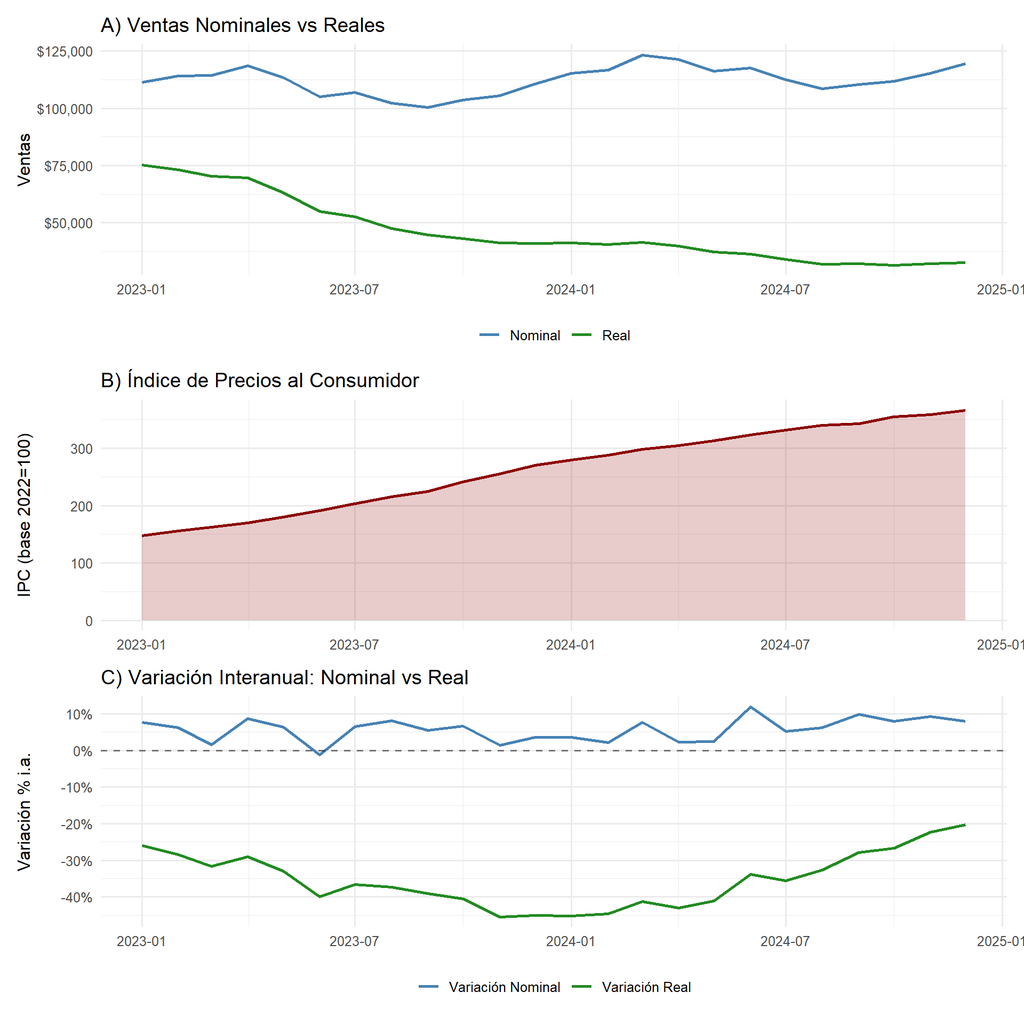

```r
# Preparar datos para visualización
datos_plot <- datos_completos %>%
  select(fecha, ventas_nominales, ventas_reales_base_2022,
         var_interanual, var_interanual_real, ipc) %>%
  filter(!is.na(var_interanual))

# Gráfico 1: Ventas nominales y reales
g1 <- ggplot(datos_plot) +
  geom_line(aes(x = fecha, y = ventas_nominales, color = "Nominal"),
            size = 1) +
  geom_line(aes(x = fecha, y = ventas_reales_base_2022, color = "Real"),
            size = 1) +
  scale_y_continuous(labels = dollar_format(prefix = "$", big.mark = ",")) +
  scale_color_manual(values = c("Nominal" = "steelblue",
                                 "Real" = "forestgreen")) +
  labs(title = "A) Ventas Nominales vs Reales",
       x = NULL, y = "Ventas", color = NULL) +
  theme(legend.position = "bottom")

# Gráfico 2: IPC
g2 <- ggplot(datos_plot, aes(x = fecha, y = ipc)) +
  geom_line(color = "darkred", size = 1) +
  geom_area(alpha = 0.2, fill = "darkred") +
  labs(title = "B) Índice de Precios al Consumidor",
       x = NULL, y = "IPC (base 2022=100)") +
  scale_y_continuous(labels = comma)

# Gráfico 3: Variaciones interanuales
g3 <- datos_plot %>%
  select(fecha, var_interanual, var_interanual_real) %>%
  pivot_longer(cols = c(var_interanual, var_interanual_real),
               names_to = "tipo",
               values_to = "valor") %>%
  mutate(tipo = case_when(
    tipo == "var_interanual" ~ "Variación Nominal",
    tipo == "var_interanual_real" ~ "Variación Real"
  )) %>%
  ggplot(aes(x = fecha, y = valor, color = tipo)) +
  geom_line(size = 1) +
  geom_hline(yintercept = 0, linetype = "dashed", alpha = 0.5) +
  scale_y_continuous(labels = percent_format(scale = 1)) +
  scale_color_manual(values = c("Variación Nominal" = "steelblue",
                                 "Variación Real" = "forestgreen")) +
  labs(title = "C) Variación Interanual: Nominal vs Real",
       x = NULL, y = "Variación % i.a.", color = NULL) +
  theme(legend.position = "bottom")

# Combinar gráficos
g1 / g2 / g3
```

# 4. Tasa de Crecimiento Anual Acumulada (TCAA)

## 4.1 Conceptos Teóricos

La **Tasa de Crecimiento Anual Acumulada** (TCAA), también conocida como **CAGR** (Compound Annual Growth Rate), mide el crecimiento promedio anual de una variable durante un período de tiempo, asumiendo un crecimiento constante.

$$TCAA =
\left(\frac{Valor_{final}}{Valor_{inicial}}\right)^{\frac{1}{n}} -
1$$

Donde $n$ es el número de años entre el valor inicial y final.

**Características importantes:**

- Suaviza las fluctuaciones año a año
- Útil para comparar tasas de crecimiento entre diferentes períodos
- Asume crecimiento exponencial constante (lo cual raramente ocurre en la realidad)
- Es una medida de tendencia, no de volatilidad

**Diferencia con otras medidas:**

- **Crecimiento promedio simple**: $(media(tasas\ anuales))$ - puede ser engañoso
- **TCAA**: considera el efecto compuesto - más precisa para períodos largos

## 4.2 Cálculo de TCAA con Tidyverse

```r
# Función para calcular TCAA
calcular_tcaa <- function(valor_inicial, valor_final, años) {
  ((valor_final / valor_inicial)^(1/años) - 1) * 100
}

# Calcular TCAA para diferentes períodos de las ventas
tcaa_ventas <- datos_completos %>%
  summarise(
    # TCAA 2022-2024 (ventas nominales)
    fecha_inicial = min(fecha),
    fecha_final = max(fecha),
    años = as.numeric(difftime(fecha_final, fecha_inicial, units = "days")) / 365.25,

    ventas_inicial = first(ventas_nominales),
    ventas_final = last(ventas_nominales),

    TCAA_nominal = calcular_tcaa(ventas_inicial, ventas_final, años),

    # TCAA de ventas reales
    ventas_real_inicial = first(ventas_reales_base_2022),
    ventas_real_final = last(ventas_reales_base_2022),

    TCAA_real = calcular_tcaa(ventas_real_inicial, ventas_real_final, años),

    # TCAA del IPC (inflación acumulada anualizada)
    ipc_inicial = first(ipc),
    ipc_final = last(ipc),

    TCAA_inflacion = calcular_tcaa(ipc_inicial, ipc_final, años)
  )

tcaa_ventas %>%
  select(años, TCAA_nominal, TCAA_real, TCAA_inflacion) %>%
  kable(digits = 2,
        caption = "Tasa de Crecimiento Anual Acumulada (período completo)",
        col.names = c("Años", "TCAA Ventas Nominales (%)",
                      "TCAA Ventas Reales (%)", "TCAA Inflación (%)"))
```

Tasa de Crecimiento Anual Acumulada (período completo)

| Años | TCAA Ventas Nominales (%) | TCAA Ventas Reales (%) | TCAA Inflación (%) |
| --- | --- | --- | --- |
| 2.92 | 5.06 | -32.31 | 55.19 |

## 4.3 TCAA por Períodos Móviles

Es útil calcular la TCAA para ventanas móviles de tiempo (por ejemplo, TCAA de los últimos 2 años):

```r
# Calcular TCAA móvil de 2 años
datos_completos <- datos_completos %>%
  arrange(fecha) %>%
  mutate(
    # TCAA de 2 años (24 meses)
    ventas_hace_2años = lag(ventas_nominales, 24),
    tcaa_2años_nominal = calcular_tcaa(ventas_hace_2años, ventas_nominales, 2),

    # TCAA de 2 años (real)
    ventas_real_hace_2años = lag(ventas_reales_base_2022, 24),
    tcaa_2años_real = calcular_tcaa(ventas_real_hace_2años, ventas_reales_base_2022, 2),

    # TCAA de 1 año (equivalente a variación interanual)
    tcaa_1año = calcular_tcaa(lag(ventas_nominales, 12), ventas_nominales, 1)
  )

# Visualizar TCAA móvil
datos_completos %>%
  filter(!is.na(tcaa_2años_nominal)) %>%
  select(fecha, tcaa_2años_nominal, tcaa_2años_real) %>%
  tail(12) %>%
  kable(digits = 2,
        col.names = c("Fecha", "TCAA 2 años Nominal (%)", "TCAA 2 años Real (%)"))
```

| Fecha | TCAA 2 años Nominal (%) | TCAA 2 años Real (%) |
| --- | --- | --- |
| 2024-01-01 | 5.59 | -36.30 |
| 2024-02-01 | 4.14 | -36.98 |
| 2024-03-01 | 4.58 | -36.66 |
| 2024-04-01 | 5.43 | -36.37 |
| 2024-05-01 | 4.34 | -37.13 |
| 2024-06-01 | 5.08 | -36.90 |
| 2024-07-01 | 5.77 | -36.09 |
| 2024-08-01 | 7.12 | -35.06 |
| 2024-09-01 | 7.68 | -33.70 |
| 2024-10-01 | 7.27 | -33.96 |
| 2024-11-01 | 5.25 | -34.91 |
| 2024-12-01 | 5.76 | -33.84 |

## 4.4 Comparación: TCAA vs Variación Interanual

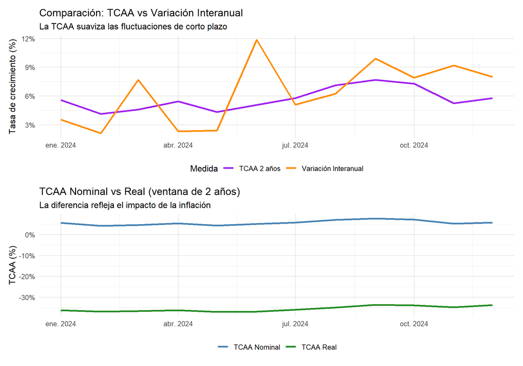

```r
# Gráfico 1: TCAA móvil vs variación interanual
p1 <- datos_completos %>%
  filter(!is.na(tcaa_2años_nominal), !is.na(var_interanual)) %>%
  select(fecha, tcaa_2años_nominal, var_interanual) %>%
  pivot_longer(cols = -fecha, names_to = "medida", values_to = "valor") %>%
  mutate(medida = case_when(
    medida == "tcaa_2años_nominal" ~ "TCAA 2 años",
    medida == "var_interanual" ~ "Variación Interanual"
  )) %>%
  ggplot(aes(x = fecha, y = valor, color = medida)) +
  geom_line(size = 1.2) +
  scale_y_continuous(labels = percent_format(scale = 1)) +
  scale_color_manual(values = c("TCAA 2 años" = "purple",
                                 "Variación Interanual" = "darkorange")) +
  labs(title = "Comparación: TCAA vs Variación Interanual",
       subtitle = "La TCAA suaviza las fluctuaciones de corto plazo",
       x = NULL, y = "Tasa de crecimiento (%)",
       color = "Medida") +
  theme(legend.position = "bottom")

# Gráfico 2: TCAA nominal vs real
p2 <- datos_completos %>%
  filter(!is.na(tcaa_2años_nominal)) %>%
  select(fecha, tcaa_2años_nominal, tcaa_2años_real) %>%
  pivot_longer(cols = -fecha, names_to = "tipo", values_to = "valor") %>%
  mutate(tipo = case_when(
    tipo == "tcaa_2años_nominal" ~ "TCAA Nominal",
    tipo == "tcaa_2años_real" ~ "TCAA Real"
  )) %>%
  ggplot(aes(x = fecha, y = valor, color = tipo)) +
  geom_line(size = 1.2) +
  scale_y_continuous(labels = percent_format(scale = 1)) +
  scale_color_manual(values = c("TCAA Nominal" = "steelblue",
                                 "TCAA Real" = "forestgreen")) +
  labs(title = "TCAA Nominal vs Real (ventana de 2 años)",
       subtitle = "La diferencia refleja el impacto de la inflación",
       x = NULL, y = "TCAA (%)",
       color = NULL) +
  theme(legend.position = "bottom")

p1 / p2
```

## 4.5 TCAA por Subperíodos

Analizar la TCAA por diferentes subperíodos permite identificar cambios en la dinámica de crecimiento:

```r
# Definir períodos de análisis
periodos <- datos_completos %>%
  mutate(
    periodo = case_when(
      fecha < "2023-01-01" ~ "2022",
      fecha < "2024-01-01" ~ "2023",
      TRUE ~ "2024"
    )
  ) %>%
  filter(periodo %in% c("2022", "2023")) %>%
  group_by(periodo) %>%
  summarise(
    fecha_inicial = min(fecha),
    fecha_final = max(fecha),
    ventas_inicial = first(ventas_nominales),
    ventas_final = last(ventas_nominales),
    ventas_real_inicial = first(ventas_reales_base_2022),
    ventas_real_final = last(ventas_reales_base_2022),
    meses = n()
  ) %>%
  mutate(
    años = meses / 12,
    TCAA_nominal = calcular_tcaa(ventas_inicial, ventas_final, años),
    TCAA_real = calcular_tcaa(ventas_real_inicial, ventas_real_final, años)
  )

periodos %>%
  select(periodo, TCAA_nominal, TCAA_real) %>%
  kable(digits = 2,
        caption = "TCAA por Año",
        col.names = c("Período", "TCAA Nominal (%)", "TCAA Real (%)"))
```

TCAA por Año

| Período | TCAA Nominal (%) | TCAA Real (%) |
| --- | --- | --- |
| 2022 | 3.23 | -26.77 |
| 2023 | -0.68 | -45.65 |

## 4.6 Proyección usando TCAA

La TCAA puede usarse para proyectar valores futuros:

$$Valor_{futuro} = Valor_{actual} \times
(1 + TCAA)^{años}$$

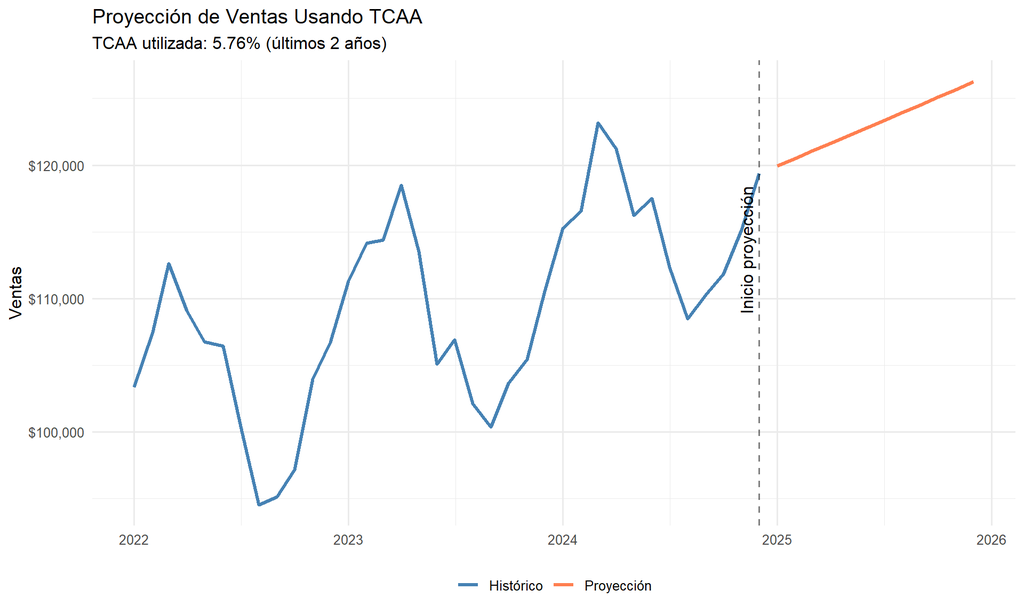

```r
# Proyectar ventas para los próximos 12 meses usando TCAA histórica
ultima_fecha <- max(datos_completos$fecha)
ultimo_valor <- last(datos_completos$ventas_nominales)

# Usar TCAA de los últimos 2 años
tcaa_proyeccion <- last(datos_completos$tcaa_2años_nominal[!is.na(datos_completos$tcaa_2años_nominal)])

proyeccion <- tibble(
  fecha = seq.Date(from = ultima_fecha + months(1),
                   to = ultima_fecha + months(12),
                   by = "month")
) %>%
  mutate(
    meses_adelante = row_number(),
    años_adelante = meses_adelante / 12,
    ventas_proyectadas = ultimo_valor * (1 + tcaa_proyeccion/100)^años_adelante,
    tipo = "Proyección"
  )

# Combinar datos históricos y proyección
datos_historicos <- datos_completos %>%
  select(fecha, ventas_nominales) %>%
  rename(ventas_proyectadas = ventas_nominales) %>%
  mutate(tipo = "Histórico")

datos_graficos <- bind_rows(datos_historicos, proyeccion)

# Visualizar
ggplot(datos_graficos, aes(x = fecha, y = ventas_proyectadas, color = tipo)) +
  geom_line(size = 1.2) +
  geom_vline(xintercept = ultima_fecha, linetype = "dashed", alpha = 0.5) +
  annotate("text", x = ultima_fecha, y = max(datos_graficos$ventas_proyectadas) * 0.9,
           label = "Inicio proyección", angle = 90, vjust = -0.5) +
  scale_y_continuous(labels = dollar_format(prefix = "$", big.mark = ",")) +
  scale_color_manual(values = c("Histórico" = "steelblue",
                                 "Proyección" = "coral")) +
  labs(title = "Proyección de Ventas Usando TCAA",
       subtitle = sprintf("TCAA utilizada: %.2f%% (últimos 2 años)", tcaa_proyeccion),
       x = NULL, y = "Ventas",
       color = NULL) +
  theme(legend.position = "bottom")
```

## 4.7 Cuándo Usar TCAA

**Usar TCAA cuando:**

- Se necesita una medida de crecimiento de largo plazo
- Se comparan crecimientos entre diferentes períodos o variables
- Se busca una tasa “suavizada” sin fluctuaciones
- Se proyectan valores futuros con tendencia constante

**NO usar TCAA cuando:**

- El período es muy corto (< 2 años)
- Hay cambios estructurales importantes en el período
- Se necesita capturar volatilidad o estacionalidad
- Los datos tienen valores negativos

**Ejemplo comparativo:**

```r
# Comparar diferentes métricas de crecimiento
comparacion_metricas <- datos_completos %>%
  filter(!is.na(var_interanual)) %>%
  summarise(
    # Crecimiento total del período
    crecimiento_total = ((last(ventas_nominales) / first(ventas_nominales)) - 1) * 100,

    # TCAA del período completo
    años_totales = as.numeric(difftime(last(fecha), first(fecha), units = "days")) / 365.25,
    TCAA = calcular_tcaa(first(ventas_nominales), last(ventas_nominales), años_totales),

    # Promedio de variaciones interanuales
    promedio_var_ia = mean(var_interanual, na.rm = TRUE),

    # Mediana de variaciones interanuales
    mediana_var_ia = median(var_interanual, na.rm = TRUE)
  )

comparacion_metricas %>%
  select(crecimiento_total, TCAA, promedio_var_ia, mediana_var_ia) %>%
  pivot_longer(everything(), names_to = "Métrica", values_to = "Valor (%)") %>%
  mutate(Métrica = case_when(
    Métrica == "crecimiento_total" ~ "Crecimiento Total",
    Métrica == "TCAA" ~ "TCAA (Compuesta)",
    Métrica == "promedio_var_ia" ~ "Promedio Var. Interanual",
    Métrica == "mediana_var_ia" ~ "Mediana Var. Interanual"
  )) %>%
  kable(digits = 2,
        caption = "Comparación de Diferentes Métricas de Crecimiento")
```

Comparación de Diferentes Métricas de Crecimiento

| Métrica | Valor (%) |
| --- | --- |
| Crecimiento Total | 7.26 |
| TCAA (Compuesta) | 3.72 |
| Promedio Var. Interanual | 5.71 |
| Mediana Var. Interanual | 6.27 |

**Interpretación:**

- El **Crecimiento Total** muestra el cambio total del período
- La **TCAA** es el crecimiento anual equivalente constante
- El **Promedio** de variaciones puede ser engañoso con volatilidad
- La **TCAA** es la métrica más robusta para períodos largos

# 5. Ejercicio Práctico Integrador

Vamos a aplicar todos los conceptos en un caso realista:

```r
# Crear datos de salarios mensuales
set.seed(789)

datos_salarios <- tibble(
  fecha = seq.Date(from = as.Date("2022-01-01"),
                   to = as.Date("2024-12-01"),
                   by = "month")
) %>%
  mutate(
    # Salario nominal creciente
    salario_nominal = 50000 * cumprod(1 + rnorm(n(), 0.04, 0.01))
  ) %>%
  left_join(ipc_data, by = "fecha") %>%
  mutate(
    # 1. Calcular salario real
    salario_real = (salario_nominal / ipc) * 100,

    # 2. Indexar salarios (base enero 2022 = 100)
    indice_salario_nominal = (salario_nominal / first(salario_nominal)) * 100,
    indice_salario_real = (salario_real / first(salario_real)) * 100,

    # 3. Calcular variaciones interanuales
    var_ia_salario_nominal = (salario_nominal / lag(salario_nominal, 12) - 1) * 100,
    var_ia_salario_real = (salario_real / lag(salario_real, 12) - 1) * 100,
    var_ia_ipc = (ipc / lag(ipc, 12) - 1) * 100,

    # 4. Calcular TCAA móvil de 2 años
    tcaa_2años_nominal = calcular_tcaa(lag(salario_nominal, 24), salario_nominal, 2),
    tcaa_2años_real = calcular_tcaa(lag(salario_real, 24), salario_real, 2)
  )

# Resumen estadístico
resumen <- datos_salarios %>%
  filter(!is.na(var_ia_salario_nominal)) %>%
  summarise(
    `Var. Media Salario Nominal` = mean(var_ia_salario_nominal),
    `Var. Media Salario Real` = mean(var_ia_salario_real),
    `Var. Media IPC` = mean(var_ia_ipc),
    `Diferencia Nominal-Inflación` = `Var. Media Salario Nominal` - `Var. Media IPC`
  )

# Calcular TCAA del período completo
tcaa_periodo <- datos_salarios %>%
  summarise(
    años = as.numeric(difftime(last(fecha), first(fecha), units = "days")) / 365.25,
    `TCAA Salario Nominal` = calcular_tcaa(first(salario_nominal), last(salario_nominal), años),
    `TCAA Salario Real` = calcular_tcaa(first(salario_real), last(salario_real), años),
    `TCAA Inflación` = calcular_tcaa(first(ipc), last(ipc), años)
  ) %>%
  select(-años)

# Combinar resúmenes
bind_rows(
  resumen %>% mutate(Tipo = "Promedios Variación I.A."),
  tcaa_periodo %>% mutate(Tipo = "TCAA Período Completo")
) %>%
  select(Tipo, everything()) %>%
  kable(digits = 2, caption = "Resumen del Ejercicio Integrador")
```

Resumen del Ejercicio Integrador

| Tipo | Var. Media Salario Nominal | Var. Media Salario Real | Var. Media IPC | Diferencia Nominal-Inflación | TCAA Salario Nominal | TCAA Salario Real | TCAA Inflación |
| --- | --- | --- | --- | --- | --- | --- | --- |
| Promedios Variación I.A. | 55.23 | -5.06 | 65.02 | -9.78 | NA | NA | NA |
| TCAA Período Completo | NA | NA | NA | NA | 54.33 | -0.56 | 55.19 |

## Visualización Final

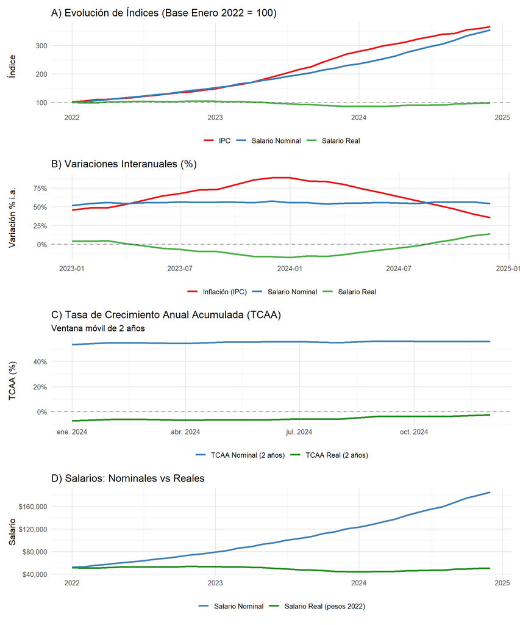

```r
# Panel 1: Índices
p1 <- datos_salarios %>%
  select(fecha, indice_salario_nominal, indice_salario_real, ipc) %>%
  pivot_longer(cols = -fecha, names_to = "variable", values_to = "valor") %>%
  mutate(variable = case_when(
    variable == "indice_salario_nominal" ~ "Salario Nominal",
    variable == "indice_salario_real" ~ "Salario Real",
    variable == "ipc" ~ "IPC"
  )) %>%
  ggplot(aes(x = fecha, y = valor, color = variable)) +
  geom_line(size = 1.2) +
  geom_hline(yintercept = 100, linetype = "dashed", alpha = 0.3) +
  scale_color_brewer(palette = "Set1") +
  labs(title = "A) Evolución de Índices (Base Enero 2022 = 100)",
       x = NULL, y = "Índice", color = NULL) +
  theme(legend.position = "bottom")

# Panel 2: Variaciones interanuales
p2 <- datos_salarios %>%
  filter(!is.na(var_ia_salario_nominal)) %>%
  select(fecha, var_ia_salario_nominal, var_ia_salario_real, var_ia_ipc) %>%
  pivot_longer(cols = -fecha, names_to = "variable", values_to = "valor") %>%
  mutate(variable = case_when(
    variable == "var_ia_salario_nominal" ~ "Salario Nominal",
    variable == "var_ia_salario_real" ~ "Salario Real",
    variable == "var_ia_ipc" ~ "Inflación (IPC)"
  )) %>%
  ggplot(aes(x = fecha, y = valor, color = variable)) +
  geom_line(size = 1.2) +
  geom_hline(yintercept = 0, linetype = "dashed", alpha = 0.3) +
  scale_y_continuous(labels = percent_format(scale = 1)) +
  scale_color_brewer(palette = "Set1") +
  labs(title = "B) Variaciones Interanuales (%)",
       x = NULL, y = "Variación % i.a.", color = NULL) +
  theme(legend.position = "bottom")

# Panel 3: TCAA móvil
p3 <- datos_salarios %>%
  filter(!is.na(tcaa_2años_nominal)) %>%
  select(fecha, tcaa_2años_nominal, tcaa_2años_real) %>%
  pivot_longer(cols = -fecha, names_to = "variable", values_to = "valor") %>%
  mutate(variable = case_when(
    variable == "tcaa_2años_nominal" ~ "TCAA Nominal (2 años)",
    variable == "tcaa_2años_real" ~ "TCAA Real (2 años)"
  )) %>%
  ggplot(aes(x = fecha, y = valor, color = variable)) +
  geom_line(size = 1.2) +
  geom_hline(yintercept = 0, linetype = "dashed", alpha = 0.3) +
  scale_y_continuous(labels = percent_format(scale = 1)) +
  scale_color_manual(values = c("steelblue", "forestgreen")) +
  labs(title = "C) Tasa de Crecimiento Anual Acumulada (TCAA)",
       subtitle = "Ventana móvil de 2 años",
       x = NULL, y = "TCAA (%)", color = NULL) +
  theme(legend.position = "bottom")

# Panel 4: Salarios en valores absolutos
p4 <- datos_salarios %>%
  select(fecha, salario_nominal, salario_real) %>%
  pivot_longer(cols = -fecha, names_to = "variable", values_to = "valor") %>%
  mutate(variable = case_when(
    variable == "salario_nominal" ~ "Salario Nominal",
    variable == "salario_real" ~ "Salario Real (pesos 2022)"
  )) %>%
  ggplot(aes(x = fecha, y = valor, color = variable)) +
  geom_line(size = 1.2) +
  scale_y_continuous(labels = dollar_format(prefix = "$", big.mark = ",")) +
  scale_color_manual(values = c("steelblue", "forestgreen")) +
  labs(title = "D) Salarios: Nominales vs Reales",
       x = NULL, y = "Salario", color = NULL) +
  theme(legend.position = "bottom")

p1 / p2 / p3 / p4
```

# 6. Conclusiones y Buenas Prácticas

## 6.1 Resumen de Conceptos

| Concepto | Fórmula | Uso Principal |
| --- | --- | --- |
| Diferencia absoluta | $\Delta X = X_t - X_{t-1}$ | Cambios en unidades originales |
| Variación % | $\frac{X_t - X_{t-1}}{X_{t-1}} \times 100$ | Cambios relativos comparables |
| Indexación | $\frac{X_t}{X_{base}} \times 100$ | Comparar evolución relativa |
| Deflactación | $\frac{X_{nominal}}{IPC} \times 100$ | Eliminar efecto inflación |
| TCAA | $\left(\frac{X_{final}}{X_{inicial}}\right)^{1/n} - 1$ | Tasa crecimiento promedio anual |

## 6.2 Buenas Prácticas con Tidyverse

```r
# 1. Usar lag() para cálculos de variaciones
data %>%
  mutate(
    var_mensual = (valor / lag(valor, 1) - 1) * 100,
    var_anual = (valor / lag(valor, 12) - 1) * 100
  )

# 2. group_by() para cálculos por grupo
data %>%
  group_by(categoria) %>%
  mutate(indice = (valor / first(valor)) * 100)

# 3. Usar funciones auxiliares para claridad
calcular_variacion <- function(x, periodos = 1) {
  (x / lag(x, periodos) - 1) * 100
}

calcular_tcaa <- function(valor_inicial, valor_final, años) {
  ((valor_final / valor_inicial)^(1/años) - 1) * 100
}

data %>%
  mutate(
    var_mensual = calcular_variacion(ventas, 1),
    var_anual = calcular_variacion(ventas, 12),
    tcaa_2años = calcular_tcaa(lag(ventas, 24), ventas, 2)
  )

# 4. Documentar la base de deflactación
deflactar <- function(nominal, ipc, base_ipc = 100) {
  (nominal / ipc) * base_ipc
}
```

## 6.3 Puntos Clave para Recordar

1. **Variaciones porcentuales** son mejores que absolutas para comparaciones
2. **Variación interanual** elimina estacionalidad
3. **Indexación** facilita comparaciones entre series diferentes
4. **Deflactación** es esencial para análisis de largo plazo
5. **TCAA** proporciona una medida suavizada de crecimiento de largo plazo
6. **El cambio de base** no afecta las tasas de variación
7. Siempre documentar claramente:
   - El periodo base utilizado
   - El deflactor empleado (IPC, IPM, etc.)
   - Las unidades de medida
   - El método de cálculo (TCAA, variación simple, etc.)